# Blunted infant pertussis responses (InfMon2 to InfMon5) vs the de Graaf CHIM ‘resistant’ adult correlate

A documented, arm-stratified algorithm that flags each GaPs infant as blunted / not-blunted on the post-priming response, then compares absolute 5-month serum IgG with the CHIM anchors (de Graaf Lancet Microbe 2026, Table 1).

Prepared for co-author review

2026-07-10

# What this document does, and why the design changed

The de Graaf controlled human infection (CHIM) study identified adults who **resisted colonisation** after *B pertussis* challenge, associated with **higher pre-inoculation serum anti-PT IgG** (a tentative correlate of protection). The co-author’s question: **do post-priming serum PT IgG concentrations in GaPs infants — especially the blunted ones — sit above the CHIM resistant-adult concentration?**

Answering that needs a **defined, reproducible “blunted” flag**, not an eyeballed subgroup. Two facts fix the design:

1. **The M02 / M05 / M09 infant draws were randomised across plates.** There is therefore *no* batch-of-plates offset between these timepoints, so the **within-subject change in concentration units is a valid response** and can be used directly (unlike the maternal/cord vs infant contrast, which required rank-standardisation in the earlier modules).
2. **The infant priming vaccine (aP vs wP) dominates the expected response.** So the expectation against which “blunted = less than expected” is judged is built **within infant arm**.

**Algorithm (one flag per subject):**

- **Response** R = log10(conc at `InfMon5`) − log10(conc at `InfMon2`) — the post-priming log fold-rise, per subject per antigen (total IgG). Requires a finite positive value at both draws.
- **Expectation**, per **infant arm** (aP, wP) separately: the arm’s own response distribution. “Expected given the exposure” = the arm-typical response.
- **Blunted** = response falls in the low tail of its arm’s response distribution. Primary rule: **below the arm’s lower tertile** (`blunt_method = "quantile"`, q = 1/3). Two sensitivity rules are also computed: **below the arm median** and **arm-standardised z below -0.4307**.
- **Validation:** the flag is cross-tabulated against the **maternal arm (TdaP vs TT)**. Because blunting is caused by maternal antibody, a valid flag should be **enriched for maternal-TdaP** among the blunted infants — this is the biological check that the statistical flag is capturing real blunting rather than noise.

**Important separation of quantities.** The *flag* is derived from the **response** (a change). The *CHIM comparison* uses the **absolute InfMon5 concentration** (a level), because the co-author is asking whether the achieved 5-month level clears the ~6.2 IU/mL resistant-adult anchor. These are deliberately different quantities and are never conflated.

# CHIM anchors — de Graaf Table 1 (published GMs, not digitized Figure 3)

de Graaf 2026 Table 1 pre-inoculation serum IgG. PT/PRN/FHA in IU/mL; FIM in AU/mL. PT anchors carried through: resistant GM = 6.2 (3.0-12.8); colonised GM = 1.9 (0.9-4.0).

| Antigen | Unit | CHIM colonised (susceptible) GM (95% CI) | CHIM resistant (protected) GM (95% CI) | p (Table 1) |
| --- | --- | --- | --- | --- |
| PT | IU/mL | 1.9 (0.9–4.0) | 6.2 (3.0–12.8) | 0.028 |
| PRN | IU/mL | 7.3 (2.4–22.3) | 17.6 (8.1–38.2) | 0.037 |
| FHA | IU/mL | 8.5 (2.5–29.2) | 30.1 (13.5–67.3) | 0.010 |
| FIM | AU/mL | 28.2 (7.4–108.0) | 25.4 (8.6–75.5) | 0.970 |

# Load `d_set` and confirm the columns

Loaded **127743** rows, **12** columns from `data/d_set.RData` (object: ebaa_extra2).

Columns: `subject_accession`, `sample_type`, `assay`, `visit_name`, `antigen`, `analyte`, `feature`, `value_reported`, `log_assay_value`, `arm_name`, `maternal_arm`, `infant_arm`

- **visit_name** (9): M00, M02, M04, M05, M09, P02, P05, P09, P18
- **antigen** (11): DT, FHA, FIM, IPV1, IPV2, IPV3, PENTAMER, PRN, PT, TT, WHOLE
- **analyte** (14): ADCD, ADCP, ADNP, Bmem, FcgR2a, FcgR3b, IgG, IgG1, IgG2, IgG3, IgG4, PTNA, SBA, WT_IgG
- **feature** (87): DT_ADCD, DT_ADCP, DT_ADNP, DT_FCGR2A, DT_FCGR3B, DT_IGG, DT_IGG1, DT_IGG2, DT_IGG3, DT_IGG4, FHA_ADCD, FHA_Bmem, FHA_FCGR2A, FHA_FCGR3B, FHA_IGG, FHA_IGG1, FHA_IGG2, FHA_IGG3, FHA_IGG4, FIM_ADCD, FIM_FCGR2A, FIM_FCGR3B, FIM_IGG, FIM_IGG1, FIM_IGG2, FIM_IGG3, FIM_IGG4, IPV1_ADCD, IPV1_FCGR2A, IPV1_FCGR3B
- **infant_arm** (2): aP, wP
- **arm_name** (4): TdaP_aP, TdaP_wP, TT_aP, TT_wP
- **subject_accession** (312): 1, 10, 101, 102, 103, 105, 106, 107, 108, 109, 11, 110, 111, 112, 113, 114, 115, 116, 117, 118, 119, 12, 120, 121, 122, 123, 124, 125, 126, 127

> Applied the project visit recode (raw codes like M02/M05 -> InfMon2/InfMon5), since the recoded labels were not already present in `d_set$visit_name`.

Infant-arm counts (rows):

infant_arm

| infant_arm | Freq |
| --- | --- |
| aP | 61209 |
| wP | 66534 |

Maternal-arm counts (rows):

arm_name (maternal)

| maternal_arm | Freq |
| --- | --- |
| TdaP_aP | 27974 |
| TdaP_wP | 33382 |
| TT_aP | 33235 |
| TT_wP | 33152 |

# Build the per-subject response and the blunting flag

Row counts after each build-response filter (find where it zeroes).

| step | rows |
| --- | --- |
| all rows | 127743 |
| analyte == total IgG | 15987 |
| + antigen in panel | 8952 |
| + visit in {InfMon2, InfMon5} | 2272 |
| + finite positive conc | 2272 |

Subjects with a usable **PT** response (finite InfMon2->InfMon5 change): **265**.

Response defined as log10(InfMon5) − log10(InfMon2), total IgG. Primary flag on **PT**; panel flag on **PT+PRN+FHA** (mean arm-standardised response z). Rule: **quantile** (below arm quantile q=0.333).

PT response by infant arm and the arm-specific blunted cut-point (quantile rule).

| Infant arm | n with PT response | Median Δlog10 rise | Blunted cut (Δlog10) | n blunted |
| --- | --- | --- | --- | --- |
| aP | 128 | 0.791 | 0.360 | 43 |
| wP | 137 | 0.030 | -0.555 | 46 |

## Validation — is the blunted flag enriched for maternal TdaP?

Blunted-PT flag x maternal arm (all infants). A valid flag should over-represent TdaP among blunted.

|  | blunted | not |
| --- | --- | --- |
| TdaP_aP | 38 | 21 |
| TdaP_wP | 41 | 31 |
| TT_aP | 5 | 64 |
| TT_wP | 5 | 60 |

Blunted-PT rate (%) by infant arm x maternal arm.

| infant_arm | maternal_arm | n | pct_blunted |
| --- | --- | --- | --- |
| aP | TT_aP | 69 | 7 |
| aP | TdaP_aP | 59 | 64 |
| wP | TT_wP | 65 | 8 |
| wP | TdaP_wP | 72 | 57 |

> Read this as the biological check: within each infant arm, maternal-TdaP infants should show a higher blunted rate than maternal-TT infants if the flag is capturing genuine maternal-antibody blunting.

# Blunting as a ceiling / threshold phenomenon (mechanistic flag)

The tertile flag above is **purely distributional** — it labels the low tail of the response distribution, agnostic to *why*. If blunting is instead a **saturation / ceiling** effect (the immune system approaches a maximum achievable antibody level, so infants who start high — lots of maternal antibody — have little headroom and respond less), the mechanistically-correct flag is different, and the two can identify almost **opposite** infants.

**Model.** On the log scale, with b = log10(InfMon2) (pre-primary maternal-antibody baseline) and y = log10(InfMon5) (achieved level): regress **y on b** per infant arm.

- slope **beta = 1** -> no blunting (vaccine adds a fixed increment regardless of baseline);
- **beta = 0** -> hard ceiling (achieved level set by the ceiling C, independent of baseline);
- **0 < beta < 1** -> partial interference.

We (1) estimate beta and test it against 1 (the coupling-robust test — we deliberately do **not** regress the response r=y-b on b, because r and b are mathematically coupled and would show a spurious negative slope even under noise); (2) fit a **segmented** model to locate a **breakpoint psi** (the threshold) and check whether the upper segment flattens (a genuine plateau); and (3) define **ceiling-blunted = baseline above psi** — the infants in the interference regime. The plateau height back-transformed is the **ceiling C in IU/mL**, directly comparable to the CHIM resistant anchor (6.2).

Ceiling/threshold fit for PT (achieved InfMon5 on baseline InfMon2, log10, per infant arm). beta=1 no blunting, beta->0 hard ceiling; p is the coupling-robust test of beta vs 1. A positive dAIC favours the segmented (ceiling) model over a single line. ‘ceiling C’ is the plateau level in IU/mL, compare with the CHIM resistant anchor 6.2.

| Infant arm | n | beta (y~b) | beta 95% CI | p(beta!=1) | breakpoint psi (IU/mL) | slope below | slope above | ceiling C (IU/mL) | dAIC seg-vs-line | n ceiling-blunted |
| --- | --- | --- | --- | --- | --- | --- | --- | --- | --- | --- |
| aP | 128 | -0.14 | -0.24–-0.05 | 0 | 1.5 | 0.05 | -0.19 | 111.6 | -0.5 | 107 |
| wP | 137 | -0.59 | -0.73–-0.45 | 0 | 35.5 | -0.82 | 0.76 | 10.4 | 12.6 | 49 |

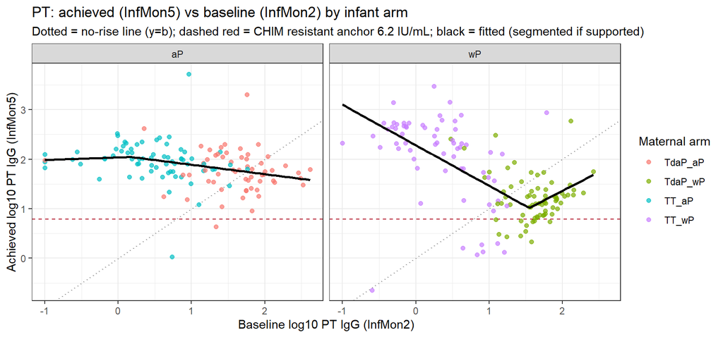